# What are the components of an R script?

Header:

1. Name (the author of the code including contact info)
2. Date (helps you organize scripts)
3. Purpose (what does this accomplish)
4. Version number (you may be annotating the same code over many years)
5. Line by line annotation

```r
# R. Leaf   July 29, 2016
# v04
# Script for R shortcourse. The script has the following components:

# 1. Documentation of scripts
# 2. Demonstration of writing code
# 3. Discussion of basic statistical tools
# 4. Etc., etc...

# Some text narrative that describes the sources, motivations, and citations. e.g.
# Crawley, Michael J. Statistics: an introduction using R. John Wiley & Sons, 2014.
```

Excecutable, annotated, organized code

Tidy and well-organized

```r
# Code to keep workspace clean
# Functions ls() and rm()
?ls
?rm
```

Order matters:

- Because R is an “interpreted language” objects must be loaded into the environment prior to using it.
- Some languages involve compiling the code - in that case order generally does not matter.
- Therefore, define object (data) and parameters in the very top of your script.

Use meaningful variable names:

- Variable names (e.g. x, g., and y are not meaningful).
- Script file names “final.r” “your.name.r” are not meaningful.
- Consider adopting a variable naming structure using meaningful abbreviations
  - “.vec”
  - “.df”
  - “.list”

Keep directory structure flexible:

- Hardcoding means that your code cannot be shared.
- Ex. a harcoded system path to your machine will not work on someone else’s machine.
- “**load()**” for example should not have a hardcoded path.

# How not to write code:

- Don’t use a script editor and write large, multi-line chunks of nested functions.
- Run this code, untested, and backtrack to discover and remedy errors.

Better programming practice: A biologists humble advice about how to code in any programming language

- Trade elegance for simplicity.
- Use a pencil and paper to write pseudocode “Broekow: Know what you are doing”
- This will be your blue print so you know where you are going.
- Each script and function will have a single or set of related objectives.
- These objectives will be clearly annotated in the header.
- Code small pieces (one or two functions) and assign the output to meaningful variable names.
- Keep the workspace clean by discarding objects (object, functions) that are created and will not be used again.
- Don’t be afraid to start over.

# Writing your own functions

Why would we be interested in writing our own functions?

- Even with thousands of packages you will need ad hoc approaches in your work.
- Many packages and associated functions are not actively maintained.
- R is updated and the package with your function of interest may not be.
- Some functions, in some packages, may not work with the idiosyncracies of your data.
- Packages are of incosistent quality in terms of documentation.
- Error trapping may not be sufficient.
- User-made functions help keep the workspace clean.
- Extraneous, unwantedobjects are not created and lurking.

From a “clean and tidy” perspective functions help keep complex code organized.

Often we do the same statistical and mathematical operations over and over again.

I recommend having a directory of well-annotated user-created scripts with meaningful file names.

Anatomy of a function:

```r
function.name <- function(x)
  {
  # braces are used to enclose the function - start open brace
  # computational operation that only deals with function argument x
  # "value to return"" is calculated
  #object value is created that can be of any data class.
  return(value)
  }   # braces are used to enclose the function - end closed brace
```

1. Function name
- A meaningful descriptor of the function.
- Name does must not already exist in base R or contributed R packages.
- So, “sum”, “mean”, “length” are poor function names
2. function(x)
- “function” is a function that takes any number of arguments.
3. Someobject or set ofobjects is computed and these are returned to the user.
- The function “return” is used.

Lets examine the structure of a function:

- function is called “command.name” that does something.
- The purpose is not important - for now we focus on teh anatomy of the command.name call

command.name(measurement, argument1 = TRUE, argument2 = 3, argument3= “vals”)

- “command.name” is the name of the command - these are specific to the program and case-sensitive
- “measurement” is a vector or column of data (numerical values or measurements) that you want to analyze, the user assigns these.
- argument1 is some “logical” argument. The default value is “True”
- argument2 is some “numeric” argument. The default value is “3”
- argument3 is some “character” argument. The default value is “vals”

Example:

- We may be interested in calculating the standard error of the mean.
- Surprisingly this function is not in base R

First step:

- Blueprint
  - Whatobjects are needed?
  - What parameters are created?
  - Will we need to import packages from outside base R?

Second step:

- Create a script that will calculate the standard error of the mean.
- We will first create some normally distributed data:

```r
?rnorm
nums = rnorm(n = 25, mean=100, sd=15)
```

- Examine the data using a figure:

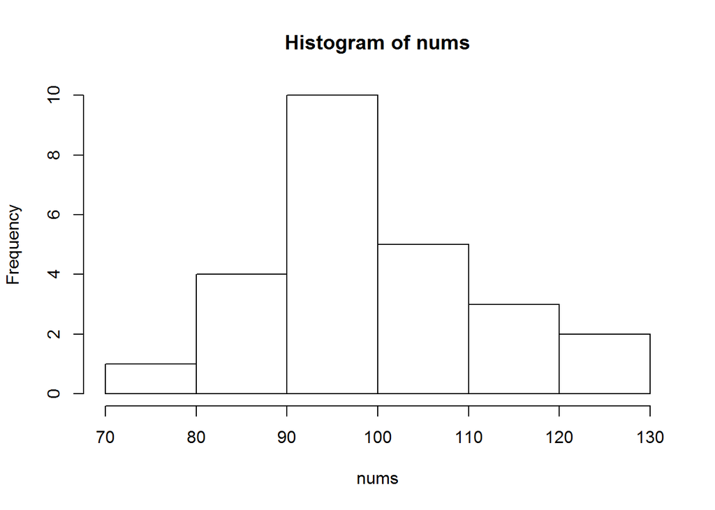

```r
?hist
hist(x = nums)
```

What quantities will we need to calculate the standard error of the mean?

1. The arithmetic mean of the data vector
2. The variance of the data vector
3. The number of elements in the data vector

```r
?stats::var
stats::var(nums)
```

```
## [1] 153.3182
```

```r
?length
length(nums)
```

```
## [1] 25
```

Now that we:

1. Have the components of what we need
2. Understand them
3. Have inspected the output We can proceed.

```r
var.num   <- var(nums)
len.num   <- length(nums)

sem <- sqrt(var.num/len.num)
```

Lets translate the above script into a generic function.

Clear workspace

```r
rm(list = ls())
```

Check environment tab to ensure that there are no lurkingobjects

```r
ls()
```

```
## character(0)
```

Check to make sure that our proposed function name “sem.fun” does not exist

```r
?sem.fun
```

```
## No documentation for 'sem.fun' in specified packages and libraries:
## you could try '??sem.fun'
```

```r
sem.fun = function(x)
{
  var.x <- var(x)
  len.x <- length(x)
sem.val <- sqrt(var.x/len.x)
return(sem.val)
}
```

Lets expand this basic code:

1. How can we make this code robust to missing values?
- How do the length and var functions deal with NA?
- Test them to ensure you know what is being calculated
2. What if we want a histogram returned as well as our calculated values?
3. What if we want to return a multi-element object? (hint: use list in the return function)
- This list will include:
  1. The original data vector
  2. Which if any of the values is/are NA
  3. Which of the values are not NA
  4. The mean of the data vector
4. Save this function with proper and appropriate annotation.

Your first step is to develop a robust script - then translate into a function.